# Modeling Wine Quality using SVC over GridSearch

In this mini-project, I attempt to replicate results in the paper by Cortez et. al. on Modeling wine preferences by data mining from physiochemical properties. The paper SVC in an attempt to predict qualities of Vinho Verde wine in Portugal, using wine characteristics (physiochemical properties) such as acidity, residual sugar, sulphur dioxide and density as training features.

I chose this project because I have always have an interest in food and I find the topic fun. Aside from that, being able to predict wine quality based on a wine's physiochemical properties, also informs wine producers on the type of wine to produce in order to appeal to the market.

# Import Data

The data used is from the paper by Cortez et. al., made available to public from the UCI Machine Learning Repostory. The data contains physiochemical characteristics of Vinho Verde from the Minho region of Portugal. Their qualities are rated by CVRVV, the official wine certification entity of Vinho Verde. The data was collected from 2004 to 2007.

Reference:

Paulo Cortez, António Cerdeira, Fernando Almeida, Telmo Matos, José Reis, Modeling wine preferences by data mining from physicochemical properties, Decision Support Systems, Volume 47, Issue 4, 2009, Pages 547-553, ISSN 0167-9236, https://doi.org/10.1016/j.dss.2009.05.016.

Dataset: Cortez, P., Cerdeira, A., Almeida, F., Matos, T., & Reis, J. (2009). Wine Quality [Dataset]. UCI Machine Learning Repository. https://doi.org/10.24432/C56S3T.

```python
# !pip install ucimlrepo

import pandas as pd
import numpy as np
from pydantic import BaseModel, Field
from typing import Optional, Any
from ucimlrepo import fetch_ucirepo
import matplotlib.pyplot as plt
import seaborn as sns
import warnings

warnings.filterwarnings("ignore")
```

```python
class ImportData(BaseModel):
  """this class manages the task of importing data from UCI ML Repository and loading data into a dataframe"""

  repoId: Optional[int] = Field(None, description="Repository ID for our dataset")
  data: Optional[Any] = None

  def grabData(self):
    """from given repId, this function downloads the data"""
    if not self.repoId:
      print(f"Please instantiate repo Id")
    else:
      try:
        self.data = fetch_ucirepo(id=self.repoId)
        return self.data
      except Exception as e:
        print(f'there is an error in fetching the data. Error code: {e}')
        return None
```

```python
importer = ImportData(repoId=186)
winequality = importer.grabData()
```

```python
X = winequality.data.features
Y = winequality.data.targets
allData = pd.concat([Y, X], axis=1)
print(Y.shape)
print(X.shape)
```

```
(6497, 1)
(6497, 11)
```

We received data with **6497 rows** of data and **11 features**. Next, we will explore this dataset in EDA

# EDA

The following plot shows the distribution of dependent variable Y. Y is a quality rating from scores 3 to 9. I observe that **the classes are imbalanced**. For example, we see little to no datapoints for scores 3 and 9, and modality is concentrated on 5 and 6. This is important because imbalance dataset will affect our metric selection down the road.

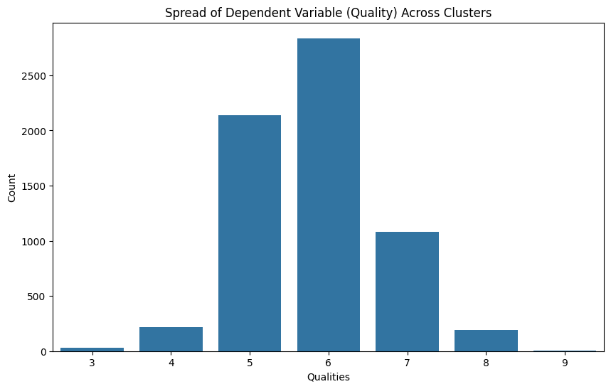

```python
Y_df = pd.DataFrame(Y.value_counts()).reset_index()
plt.figure(figsize=(10, 6))

sns.barplot(x='quality', y='count',  data=Y_df)

plt.xlabel('Qualities')
plt.ylabel('Count')
plt.title('Spread of Dependent Variable (Quality) Across Clusters')
plt.show()
```

The following is an exploration of the feature set X. The features contain physiochemical properties for the wines (for example fixed acidity, citric acid, residual sugar etc). Some interesting observations:

1. We see from the boxplot and descriptive statistics that there are **significant outliers** in our dataset
2. We see from the correlation matrix that the **features do not seem to be overally correlated with our dependent variable** quality. Features like alcohol, density(negative), volatile acidity (negative), have some weak correlation (between absolute value of 0.2 to 04)

[output not shown]

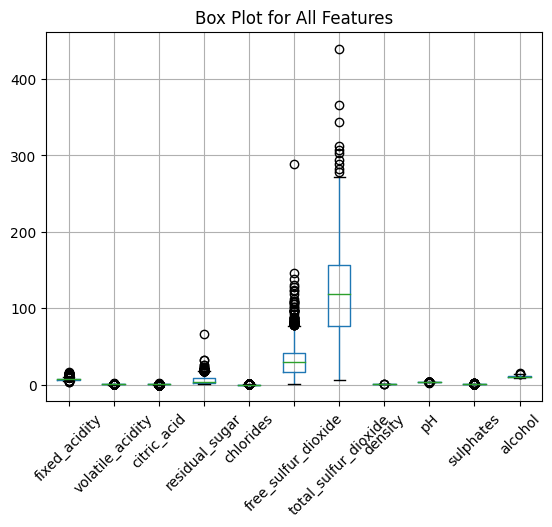

```python
X.boxplot()
plt.title("Box Plot for All Features")
plt.xticks(rotation=45)
```

```python
round(X.describe(),2)
```

|  | fixed_acidity | volatile_acidity | citric_acid | residual_sugar | chlorides | free_sulfur_dioxide | total_sulfur_dioxide | density | pH | sulphates | alcohol |
| --- | --- | --- | --- | --- | --- | --- | --- | --- | --- | --- | --- |
| count | 6497.00 | 6497.00 | 6497.00 | 6497.00 | 6497.00 | 6497.00 | 6497.00 | 6497.00 | 6497.00 | 6497.00 | 6497.00 |
| mean | 7.22 | 0.34 | 0.32 | 5.44 | 0.06 | 30.53 | 115.74 | 0.99 | 3.22 | 0.53 | 10.49 |
| std | 1.30 | 0.16 | 0.15 | 4.76 | 0.04 | 17.75 | 56.52 | 0.00 | 0.16 | 0.15 | 1.19 |
| min | 3.80 | 0.08 | 0.00 | 0.60 | 0.01 | 1.00 | 6.00 | 0.99 | 2.72 | 0.22 | 8.00 |
| 25% | 6.40 | 0.23 | 0.25 | 1.80 | 0.04 | 17.00 | 77.00 | 0.99 | 3.11 | 0.43 | 9.50 |
| 50% | 7.00 | 0.29 | 0.31 | 3.00 | 0.05 | 29.00 | 118.00 | 0.99 | 3.21 | 0.51 | 10.30 |
| 75% | 7.70 | 0.40 | 0.39 | 8.10 | 0.06 | 41.00 | 156.00 | 1.00 | 3.32 | 0.60 | 11.30 |
| max | 15.90 | 1.58 | 1.66 | 65.80 | 0.61 | 289.00 | 440.00 | 1.04 | 4.01 | 2.00 | 14.90 |

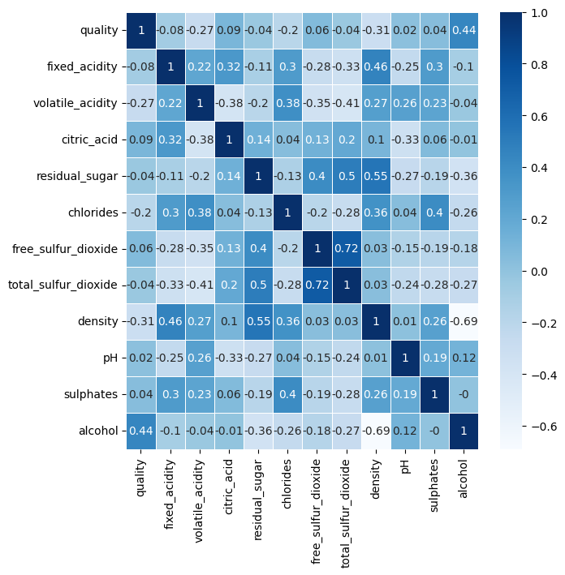

```python
fig, ax = plt.subplots(figsize=(7,7))
g= sns.heatmap(allData.corr().round(2), cmap='Blues', annot=True, linewidths=.5, ax=ax)
```

# Data Cleaning

### Removing classes 3 and 9 in Y

From the EDA, we learn that classes 3 and 9 have barely any responses in our dataset, therefore, there is no power in training for these classes. They should be removed from the dataset.

```python
Y2 = Y[(Y['quality'] != 3) & (Y['quality'] != 9)]
X2 = X[(Y['quality'] != 3) & (Y['quality'] != 9)]
```

### Outlier detection and removal

From EDA, we learn that there are significant outliers in our dataset, particularly for features fixed_acidity, citric_acid, free_sulfur_dioxide. We use descriptive statistics to guide us on the threshold to remove such datapoints

```python
Y2 = Y2[(X2['fixed_acidity'] < 12) &
               (X2['citric_acid'] < 0.6) &
               (X2['free_sulfur_dioxide'] < 100)]
X2 = X2[(X2['fixed_acidity'] < 12) &
               (X2['citric_acid'] < 0.6) &
               (X2['free_sulfur_dioxide'] < 100)]
```

```python
print(X.shape)
print(Y.shape)
print(X2.shape)
print(Y2.shape)
```

```
(6497, 11)
(6497, 1)
(6163, 11)
(6163, 1)
```

The resultant boxplot is now much better compared to previous plot

[output not shown]

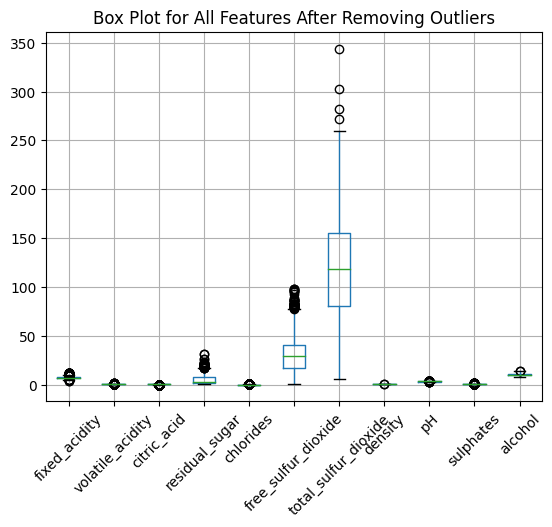

```python
X2.boxplot()
plt.title("Box Plot for All Features After Removing Outliers")
plt.xticks(rotation=45)
```

### Feature Engineering: using unsupervised method to create labels for White Wine and Red Wine

In the paper, the author mentioned that the samples contained 1599 red wines and 4898 white wines.

- However, as you see from the given X and Y attributes above, we only have physiochemical data of the wine and the author did not release the labels for red and white wine.
- The paper also stated that red and white wine have distinct physiochemical properties. Here I use clustering methods on our datasets to derive a proxy for red and white wines.
- I find that using K-means clustering on first principal component of our feature results in two clusters of dataset that have very similar physiochemical data characteristics for the red and white wines in the paper. Therefore, I will use these sample clusters as proxies for Red and White wines.

```python
from sklearn.preprocessing import StandardScaler
from sklearn.cluster import KMeans
import itertools
from mpl_toolkits.mplot3d import Axes3D
from sklearn.decomposition import PCA
```

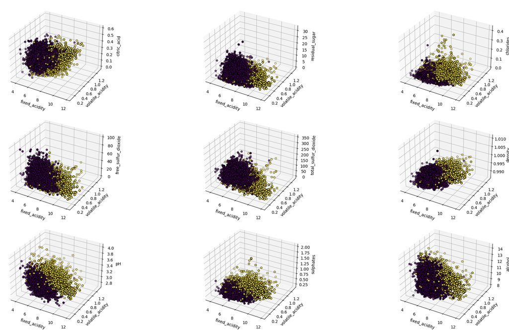

```python
X_standard = pd.DataFrame(StandardScaler().fit_transform(X2)) # Standardization to do PCA

pca = PCA(n_components=1) # PCA with 1 principal component
X_pca = pca.fit_transform(X_standard)

kmeans = KMeans(n_clusters=2) # K-means with 2 clusters
kmeans.fit(X_pca) # Use K-means on X projected upon first principal component

clusters = kmeans.labels_ # obtain cluster labels on data

# include cluster label to our dataset
X2['cluster'] = clusters
X_standard['cluster'] = clusters
Y2['cluster'] = clusters
columns = X2.columns[:-1]
combinations = list(itertools.combinations(columns, 3))[:9]

# plot separation of cluster across various features in X
fig = plt.figure(figsize=(20, 15))
for i, (col1, col2, col3) in enumerate(combinations, 1):
    ax = fig.add_subplot(4, 3, i, projection='3d')
    ax.scatter(X2[col1], X2[col2], X2[col3], c=X2['cluster'], cmap='viridis', edgecolor='k')
    ax.set_xlabel(col1)
    ax.set_ylabel(col2)
    ax.set_zlabel(col3)

plt.tight_layout()
plt.show()
```

From the diagram above, across the features it would seem that we have somewhat clear separation between the clusters. When we count the number of instances in each cluster, we find that they are somewhat close to the actual counts in the paper (4898 White and 1599 Red):

```python
X2['clusterLabel'] = np.where(X2['cluster'] == 0, 'White', 'Red')
X_standard['clusterLabel'] = np.where(X_standard['cluster'] == 0, 'White', 'Red')
Y2['clusterLabel'] = np.where(Y2['cluster'] == 0, 'White', 'Red')

X2['clusterLabel'].value_counts()
```

| clusterLabel | count |
| --- | --- |
| White | 4523 |
| Red | 1640 |

**dtype:** int64

The summarized physiochemical data bewteen our clustered datapoints, and the ones for Red and White in the paper, are very close. Therefore, our cluster is a good enough proxy for red and white

```python
pd.set_option('display.max_rows', None)
pd.set_option('display.max_columns', None)
round(X2.groupby('clusterLabel').describe().transpose().unstack(level=0),2)
```

| clusterLabel | Red fixed_acidity | Red volatile_acidity | Red citric_acid | Red residual_sugar | Red chlorides | Red free_sulfur_dioxide | Red total_sulfur_dioxide | Red density | Red pH | Red sulphates | Red alcohol | Red cluster | White fixed_acidity | White volatile_acidity | White citric_acid | White residual_sugar | White chlorides | White free_sulfur_dioxide | White total_sulfur_dioxide | White density | White pH | White sulphates | White alcohol | White cluster |
| --- | --- | --- | --- | --- | --- | --- | --- | --- | --- | --- | --- | --- | --- | --- | --- | --- | --- | --- | --- | --- | --- | --- | --- | --- |
| count | 1640.00 | 1640.00 | 1640.00 | 1640.00 | 1640.00 | 1640.00 | 1640.00 | 1640.00 | 1640.00 | 1640.00 | 1640.00 | 1640.0 | 4523.00 | 4523.00 | 4523.00 | 4523.00 | 4523.00 | 4523.00 | 4523.00 | 4523.00 | 4523.00 | 4523.00 | 4523.00 | 4523.0 |
| mean | 7.88 | 0.52 | 0.24 | 2.46 | 0.08 | 15.91 | 51.62 | 1.00 | 3.32 | 0.64 | 10.49 | 1.0 | 6.85 | 0.27 | 0.33 | 6.46 | 0.04 | 35.69 | 139.46 | 0.99 | 3.19 | 0.49 | 10.51 | 0.0 |
| std | 1.45 | 0.18 | 0.17 | 1.39 | 0.04 | 9.95 | 35.05 | 0.00 | 0.15 | 0.17 | 1.13 | 0.0 | 0.82 | 0.09 | 0.09 | 4.98 | 0.02 | 15.53 | 40.91 | 0.00 | 0.15 | 0.11 | 1.21 | 0.0 |
| min | 4.60 | 0.10 | 0.00 | 0.70 | 0.01 | 1.00 | 6.00 | 0.99 | 2.77 | 0.25 | 8.50 | 1.0 | 3.80 | 0.08 | 0.00 | 0.60 | 0.01 | 2.00 | 18.00 | 0.99 | 2.72 | 0.22 | 8.00 | 0.0 |
| 25% | 6.90 | 0.39 | 0.09 | 1.80 | 0.06 | 8.00 | 24.00 | 0.99 | 3.22 | 0.54 | 9.50 | 1.0 | 6.30 | 0.21 | 0.27 | 1.80 | 0.04 | 24.00 | 110.00 | 0.99 | 3.09 | 0.41 | 9.50 | 0.0 |
| 50% | 7.60 | 0.52 | 0.24 | 2.10 | 0.08 | 14.00 | 43.00 | 1.00 | 3.32 | 0.61 | 10.20 | 1.0 | 6.80 | 0.26 | 0.31 | 5.40 | 0.04 | 34.00 | 135.00 | 0.99 | 3.18 | 0.47 | 10.40 | 0.0 |
| 75% | 8.80 | 0.64 | 0.37 | 2.60 | 0.09 | 21.00 | 72.00 | 1.00 | 3.41 | 0.72 | 11.20 | 1.0 | 7.30 | 0.32 | 0.38 | 9.90 | 0.05 | 46.00 | 168.00 | 1.00 | 3.28 | 0.54 | 11.40 | 0.0 |
| max | 11.90 | 1.33 | 0.59 | 15.50 | 0.42 | 68.00 | 220.00 | 1.00 | 4.01 | 1.98 | 14.05 | 1.0 | 10.70 | 0.93 | 0.59 | 31.60 | 0.35 | 98.00 | 344.00 | 1.01 | 3.82 | 1.08 | 14.20 | 0.0 |

```python
# """ This section is for uploading a PDF of the Physicochemical Data Statistics per Wine type in the Paper"""
# from google.colab import files
# from io import BytesIO
# from PIL import Image
# import matplotlib.pyplot as plt


# uploaded = files.upload()
# print(uploaded)
```

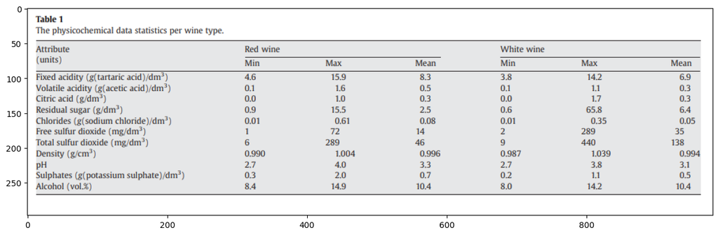

```python
im = Image.open(BytesIO(uploaded['physiochemicalDataStatisticsPerWine.png']))
plt.figure(figsize=(15, 22))
plt.imshow(im)
plt.show()
```

Now that we have performed EDA, cleaned the data, generated feature for Red and White wines, we are ready to train a model on it

# Support Vector Machine using Grid Search over various parameters

**Model:** paper recommends that we use Support Vector Machine to train the model. The paper also suggests that we use RBF kernel (has less parameter), and that SVM on this dataset is sensitive to hyperparameters C (the margin of boundary) and gamma. Here I will tune these two hyperparameters using a 5-fold cross validation grid search

**Metric Evaluation**: Given that from EDA we see an imbalanced class, accuracy may not be the best metric. Instead, I will use **weighted-f1** score as the metric to tune and build the model (weighted because this is a multiclass model). However, I will then look at the confusion metrics and all the relevant metrics (accuracy, f1, recall, precision) to get a full picture of the model performance.

```python
from sklearn.model_selection import GridSearchCV, train_test_split
from sklearn.metrics import confusion_matrix, ConfusionMatrixDisplay, accuracy_score, precision_score, recall_score, f1_score
from sklearn.svm import SVC
from numpy import math
```

```python
class SVMGridSearch:
  """ Handles the tasks of running Grid Search over a parameter grid on an SVM model, retain and plotting results"""

  def __init__(self,X,Y,clabel):
    self.X = X
    self.Y = Y
    self.clabel = clabel
    self.gridSearch = None
    self.searchResults = None
    self.bestParam = None
    self.bestScore = None

  def filterLabel(self):
    """prepares data for training"""
    Xfilter = self.X[self.X['clusterLabel'] == self.clabel].drop(['clusterLabel', 'cluster'], axis = 1)
    Yfilter = self.Y[self.Y['clusterLabel'] == self.clabel].drop(['clusterLabel', 'cluster'], axis = 1)
    return Xfilter, Yfilter

  def runGridSearch(self,paramGrid, scoringMethod):
    """runs the grid search over given parameter grid and scoring method"""
    Xdrop, Ydrop = self.filterLabel()
    self.gridSearch = GridSearchCV(SVC(), paramGrid, cv=5, scoring = scoringMethod)
    self.gridSearch.fit(Xdrop, Ydrop)

    self.searchResults = pd.DataFrame(self.gridSearch.cv_results_)
    self.bestParam = self.gridSearch.best_params_
    self.bestScore = self.gridSearch.best_score_

  def plotHeatMap(self, param1, param2):
    """plot heatmap of gridsearch based on the stated parameters"""
    heatmap_df = self.searchResults.pivot(index=param1, columns=param2, values='mean_test_score')
    plt.figure(figsize=(8, 6))
    sns.heatmap(heatmap_df, annot=True, fmt='.3f', cmap='viridis')
    plt.title(f"Heatmap of F1 Score for {self.clabel} ({param1} vs {param2})")
    plt.xlabel(f'{param2}')
    plt.ylabel(f'{param1}')
    plt.show()

  def plotConfMatrix(self):
    """plot confusion matrix for best model"""
    Xdrop, Ydrop = self.filterLabel()
    Ypred = self.gridSearch.best_estimator_.predict(Xdrop)
    CM = confusion_matrix(Ydrop, Ypred)

    # print out relevant scores
    f1 = f1_score(Ydrop, Ypred, average='weighted')
    print(f"F1 Score: {f1:.2f}")

    precision = precision_score(Ydrop, Ypred, average='weighted')
    print(f"Precision: {precision:.2f}")

    recall = recall_score(Ydrop, Ypred, average='weighted')
    print(f"Recall: {recall:.2f}")

    accuracy = accuracy_score(Ydrop, Ypred)
    print(f"Accuracy: {accuracy:.2f}")

    # plot

    plt.figure(figsize=(6, 4))
    sns.heatmap(CM, annot=True, fmt='d', cmap='Blues', cbar=False)
    plt.title(f"Confusion Matrix for {self.clabel}")
    plt.xlabel("Predicted")
    plt.ylabel("Actual")
    plt.show()
```

```python
param_grid = {
    'kernel': ['rbf'],
    'C': [0.01, 0.1,1, 10, 50, 100, 500, 1000],
    'gamma': [0.0001, 0.001, 0.01, 0.1, 1]
}

SVMRed = SVMGridSearch(X_standard, Y2, clabel='Red')
SVMRed.runGridSearch(param_grid, 'f1_weighted')

SVMWhite = SVMGridSearch(X_standard, Y2, clabel='White')
SVMWhite.runGridSearch(param_grid, 'f1_weighted')
```

The outputs below show

1. A heatmap of parameter gamma against C, and the resulting f1-weighted scores. We find that the best f1-weighted scores are obtained for Red around C = 10 and gamma = 0.01 regions, and for White around C = 50 and gamma = 0.01 regions
2. Using these hyperparameters, the confusion matrix shows that the final accuracy scores for Red is about 60% for both Red and White wines.

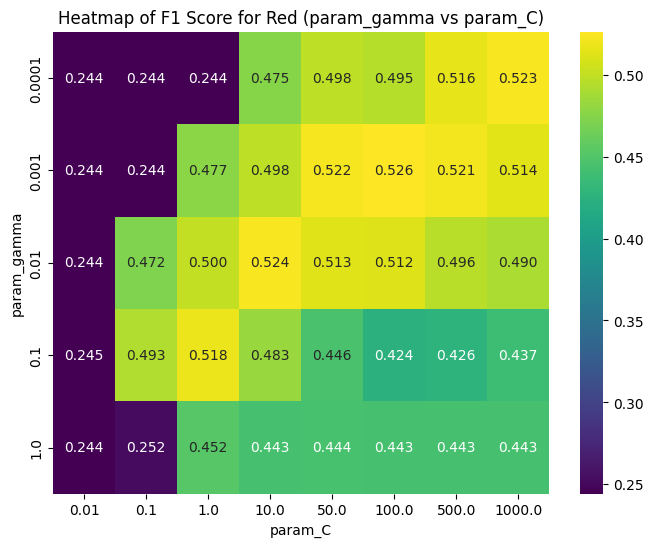

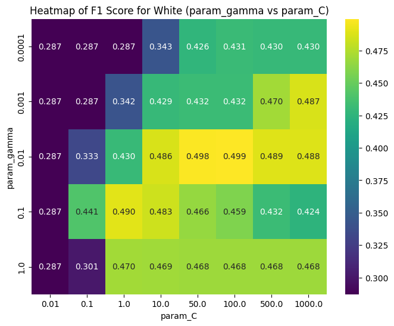

```python
SVMRed.plotHeatMap('param_gamma', 'param_C')
SVMWhite.plotHeatMap('param_gamma', 'param_C')
```

```
F1 Score: 0.57
Precision: 0.56
Recall: 0.60
Accuracy: 0.60
```

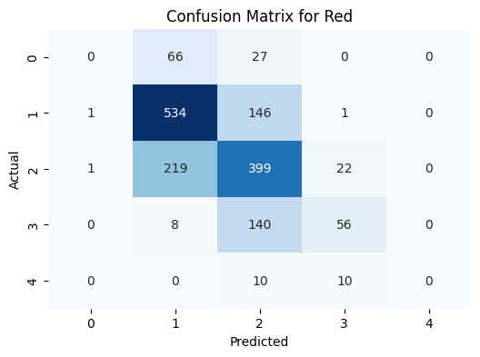

```
F1 Score: 0.56
Precision: 0.56
Recall: 0.59
Accuracy: 0.59
```

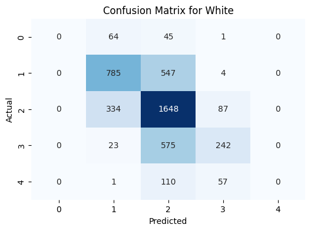

```python
# confusion matrix for best Model
SVMRed.plotConfMatrix()
SVMWhite.plotConfMatrix()
```

# Discussion

Based on the results above, I was able to replicate one of the results in the paper. The result was close to what the authors have obtained when the **tolerence** parameter was set at 0.5. When the authors increases the tolerence parameter to 1, they were able to achieve accuracy of as high as over 80%. I did not play around with the tolerence factor, as I was unsure if the tolerence factor is parameter to be adjusted in SVC, or if this was the tolerence of classification class in the final output. When I did perform a grid search on the tolerence in the SVC model (not shown in this work), my accuracy score was unchanged from above.

# Concluding Remarks

In this mini-project, I attempt to replicate the results of the paper by Cortez et. al. on modeling wine preferences by data mining from physiochemical properties. I followed the instructions in the paper to treat outliers, removing classes that received little responses, and used the SVM model over a grid search parameter. Furthermore, because the paper separates the analysis by Red and White wines, but the data supplied from the UCI repository did not have the labels for red and white, I had to generate this label as a feature engineering exercise. Some of the observations and lessons learned:

1. K-means clustering on the first principal component of feature set, was able to produce 2 clusters that were great proxies for Red and White wine. I am excited to extend this technique to other food related classification tasks, to test out the potential of using unsupervised learning methods on physiochemical properties on food.
2. Using the recommended model (SVC with grid search over parameters C and gamma), I was able to replicate one of the results stated by the author. There remains room for improvement in my results, particularly understanding the importance of **tolerence** factor, to achieve a high percentage of accuracy as stated in the model.